# DivvyTripdata-2022-april-to-september

Rama

2022-10-20

## Latar Belakang Studi Kasus

Studi Kasus ini menggunakan data set Divvy Tripp from April 2022 to September 2022 “(found here: https://divvy-tripdata.s3.amazonaws.com/index.html).”

### Tentang Perusahaan

Pada 2016, Cyclistic meluncurkan penawaran berbagi sepeda yang sukses. Sejak itu, program tersebut telah berkembang menjadi armada 5.824 sepeda yang dilacak secara geografis dan dikunci ke dalam jaringan 692 stasiun di seluruh Chicago. Sepeda dapat diakses dari satu stasiun dan dikembalikan ke stasiun lainnya kapan pun di dalam sistem.

Sampai saat ini, strategi pemasaran Cyclistic mengandalkan upaya untuk membangun kesadaran umum dan menarik segmen konsumen yang luas. Salah satu pendekatan yang membantu mewujudkan hal ini adalah fleksibilitas harga: tiket sekali jalan, tiket sehari penuh, dan keanggotaan tahunan. Pelanggan yang membeli tiket sekali jalan atau tiket sehari penuh disebut sebagai pengendara Casual. Pelanggan yang membeli keanggotaan tahunan adalah anggota Cyclistic (member).

### Tiga pertanyaan:

1. Bagaimana anggota tahunan dan pengendara biasa menggunakan sepeda secara berbeda?
2. Mengapa pengendara biasa membeli keanggotaan tahunan Cyclistic?
3. Bagaimana Cyclistic menggunakan media digital untuk mempengaruhi pengendara biasa untuk menjadi anggota?

### Tahap Persiapan

studi kasus ini menggunakan library tidyverse, lubridate, dan ggplot2

```r
library(dplyr)
library(tidyverse)
library(lubridate)
```

```r
library(ggplot2)
library(janitor)
```

### Import File

```r
tripdata_01 <- read.csv("202204-divvy-tripdata.csv") %>% clean_names()
tripdata_02 <- read.csv("202205-divvy-tripdata.csv") %>% clean_names()
tripdata_03 <- read.csv("202206-divvy-tripdata.csv") %>% clean_names()
tripdata_04 <- read.csv("202207-divvy-tripdata.csv") %>% clean_names()
tripdata_05 <- read.csv("202208-divvy-tripdata.csv") %>% clean_names()
tripdata_06 <- read.csv("202209-divvy-tripdata.csv") %>% clean_names()
```

untuk membaca file, masing-masing menggunakan read.csv untuk membaca file tersebut dan disimpan ke dalam data frame tripdata_

## Tahap Proses

untuk memastikan data yang dibutuhkan konsisten format dan nama kolomnya, menggunakan fungsi “colnames” dan “str”

### menggabungkan semua file menjadi satu

```r
all_trips <- bind_rows(tripdata_01, tripdata_02, tripdata_03, tripdata_04, tripdata_05, tripdata_06)
```

### membuang kolom yang tidak diperlukan

beberapa kolom tidak dibutuhkan jadi dibuang dalam data.frame yang dibuat

```r
all_trips <- all_trips %>%  select(-c(start_lat, start_lng, end_lat, end_lng))
```

### pemecahan kolom started_at

memecah kolom “started_at” menyimpannya ke beberapa kolom baru dengan memisahkan tanggal, bulan, tahun, dan membuat kolom tambahan dari tanggal numeric menjadi nama hari

```r
all_trips$date <- as.Date(all_trips$started_at)
all_trips$month <- format(as.Date(all_trips$date), "%m")
all_trips$day <- format(as.Date(all_trips$date), "%d")
all_trips$year <- format(as.Date(all_trips$date), "%Y")
all_trips$day_of_week <- format(as.Date(all_trips$date), "%A")
```

fungsi (“%d/%m/%Y”) digunakan untuk format day, month, Year(4 digit), “%A” mengubah tanggal (angka) yang ada di kolom day_of_week menjadi nama hari berdasarkan data tersebut.

```r
head(all_trips)
```

```
##            ride_id rideable_type          started_at            ended_at
## 1 3564070EEFD12711 electric_bike 2022-04-06 17:42:48 2022-04-06 17:54:36
## 2 0B820C7FCF22F489  classic_bike 2022-04-24 19:23:07 2022-04-24 19:43:17
## 3 89EEEE32293F07FF  classic_bike 2022-04-20 19:29:08 2022-04-20 19:35:16
## 4 84D4751AEB31888D  classic_bike 2022-04-22 21:14:06 2022-04-22 21:23:29
## 5 5664BCF0D1DE7A8B electric_bike 2022-04-16 15:56:30 2022-04-16 16:02:11
## 6 AA9EB7BD2E1FC128  classic_bike 2022-04-21 16:52:33 2022-04-21 16:56:51
##            start_station_name start_station_id         end_station_name
## 1      Paulina St & Howard St              515  University Library (NU)
## 2   Wentworth Ave & Cermak Rd            13075    Green St & Madison St
## 3        Halsted St & Polk St     TA1307000121    Green St & Madison St
## 4   Wentworth Ave & Cermak Rd            13075 Delano Ct & Roosevelt Rd
## 5        Halsted St & Polk St     TA1307000121  Clinton St & Madison St
## 6 Desplaines St & Randolph St            15535      Canal St & Adams St
##   end_station_id member_casual       date month day year day_of_week
## 1            605        member 2022-04-06    04  06 2022   Wednesday
## 2   TA1307000120        member 2022-04-24    04  24 2022      Sunday
## 3   TA1307000120        member 2022-04-20    04  20 2022   Wednesday
## 4   KA1706005007        casual 2022-04-22    04  22 2022      Friday
## 5   TA1305000032        member 2022-04-16    04  16 2022    Saturday
## 6          13011        member 2022-04-21    04  21 2022    Thursday
```

menampilkan ringkasan isi tabel

### membuat kolom baru ride_length

```r
all_trips$ride_length <- difftime(all_trips$ended_at,all_trips$started_at)
```

isi dari kolom ride_length adalah durasi pengendara dalam mengendarai sepeda, hasil tersebut didapat dari perbedaan waktu antara kolom “started_at” dengan kolom “ended_at”

### mengubah tipe data

```r
head(all_trips$ride_length)
```

```
## Time differences in secs
## [1]  708 1210  368  563  341  258
```

```r
all_trips$ride_length <- as.numeric(as.character(all_trips$ride_length))
```

kolom ride_length memiliki tipe data karakter yaitu secs, dan mengubahnya ke numerik

ringkasang cepat untuk kolom ride_length

```r
summary(all_trips$ride_length)
```

```
##    Min. 1st Qu.  Median    Mean 3rd Qu.    Max.
## -621201     375     665    1245    1190 2175468
```

setelah mendapatkan ringkasan cepat, ternyata minimum ride_length terdapat angka kurang dari 0, untuk itu membuat data baru dengan kondisi kolom ride length tidak kurang dari 0

### Pembuatan Tabel Baru

membuat tabel baru dari data yang telah disiapkan, sebelum melakukan analisis

```r
all_trips_v2 <- all_trips[!(all_trips$ride_length<0),]
```

## Tahap Analisis

menggunakan fungsi summary untuk melihat median, mean, max, min dari kolom “ride_length”

```r
summary(all_trips_v2$ride_length)
```

```
##    Min. 1st Qu.  Median    Mean 3rd Qu.    Max.
##       0     376     665    1245    1190 2175468
```

mencari nilai maximum tiap pengendara dari kolom ride_length berdasarkan harian, agar rapih mengurutkan kolom day_of_week dimulai dari hari minggu

```r
all_trips_v2$day_of_week <- ordered(all_trips_v2$day_of_week, levels=c("Sunday", "Monday","Tuesday", "Wednesday", "Thursday","Friday", "Saturday"))

aggregate(all_trips_v2$ride_length ~ all_trips_v2$member_casual + all_trips_v2$day_of_week, FUN = max)
```

```
##    all_trips_v2$member_casual all_trips_v2$day_of_week all_trips_v2$ride_length
## 1                      casual                   Sunday                  2175468
## 2                      member                   Sunday                    89997
## 3                      casual                   Monday                  1922127
## 4                      member                   Monday                    89997
## 5                      casual                  Tuesday                  1865151
## 6                      member                  Tuesday                    89997
## 7                      casual                Wednesday                  2149238
## 8                      member                Wednesday                    89997
## 9                      casual                 Thursday                  1861410
## 10                     member                 Thursday                    89996
## 11                     casual                   Friday                  1944178
## 12                     member                   Friday                    89998
## 13                     casual                 Saturday                  2052529
## 14                     member                 Saturday                    89996
```

mencari nilai rata-rata pada kolom ride_length berdasarkan tipe pengendara dan hari

```r
all_trips_v2 %>% mutate(weekday = wday(started_at, label = TRUE)) %>%
  drop_na() %>%
  group_by(member_casual, weekday) %>%
  summarise(number_of_rides=n(),
            average_duration = mean(ride_length)) %>%
  arrange(member_casual, weekday)
```

```
## # A tibble: 14 × 4
## # Groups:   member_casual [2]
##    member_casual weekday number_of_rides average_duration
##    <chr>         <ord>             <int>            <dbl>
##  1 casual        Sun              303219            2057.
##  2 casual        Mon              213918            1833.
##  3 casual        Tue              210977            1625.
##  4 casual        Wed              210752            1527.
##  5 casual        Thu              244138            1564.
##  6 casual        Fri              274712            1733.
##  7 casual        Sat              379816            1997.
##  8 member        Sun              260784             879.
##  9 member        Mon              302657             767.
## 10 member        Tue              346228             761.
## 11 member        Wed              344013             754.
## 12 member        Thu              359010             773.
## 13 member        Fri              328270             780.
## 14 member        Sat              307523             887.
```

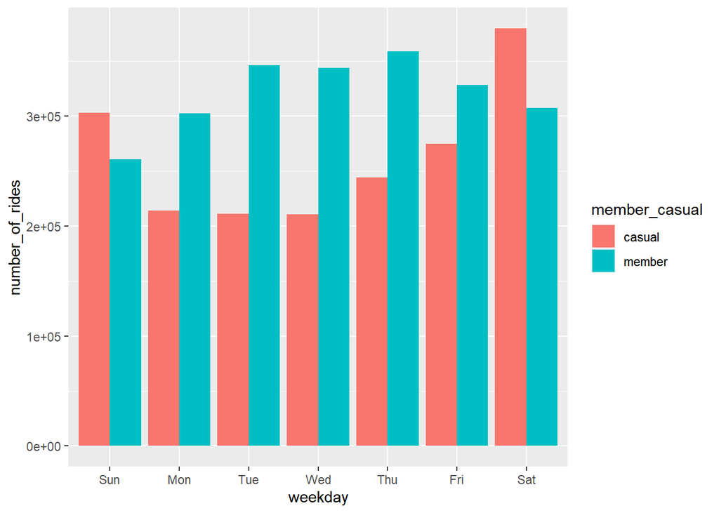

```r
all_trips_v2 %>% mutate(weekday = wday(started_at, label = TRUE)) %>%
  drop_na() %>%
  group_by(member_casual, weekday) %>%
  summarise(number_of_rides=n(),
            average_duration = mean(ride_length)) %>%
  arrange(member_casual, weekday) %>%
  ggplot(aes(weekday, number_of_rides, fill=member_casual, ylim(0,3500000)))+
  geom_col(position = "dodge")
```

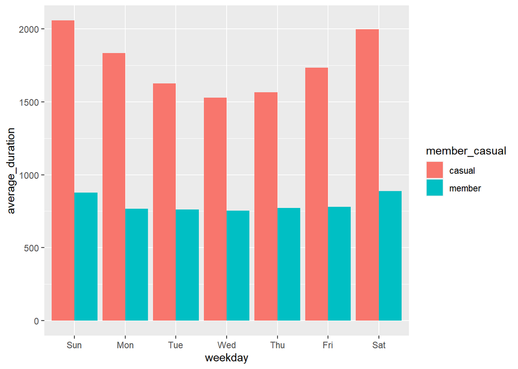

```r
all_trips_v2 %>% mutate(weekday = wday(started_at, label = TRUE)) %>%
  drop_na() %>%
  group_by(member_casual, weekday) %>%
  summarise(number_of_rides=n(),
            average_duration = mean(ride_length)) %>%
  arrange(member_casual, weekday) %>%
  ggplot(aes(weekday, average_duration , fill=member_casual))+
  geom_col(position = "dodge")
```

diagram di atas adalah rata-rata tiap pengendara berdasarkan berapa lama tiap pengendara melakukan perjalanan berdasarkan harian.Diagram menunjukkan bahwa pengendara casual 2x lebih lama dibandingkan dengan pengendara member.

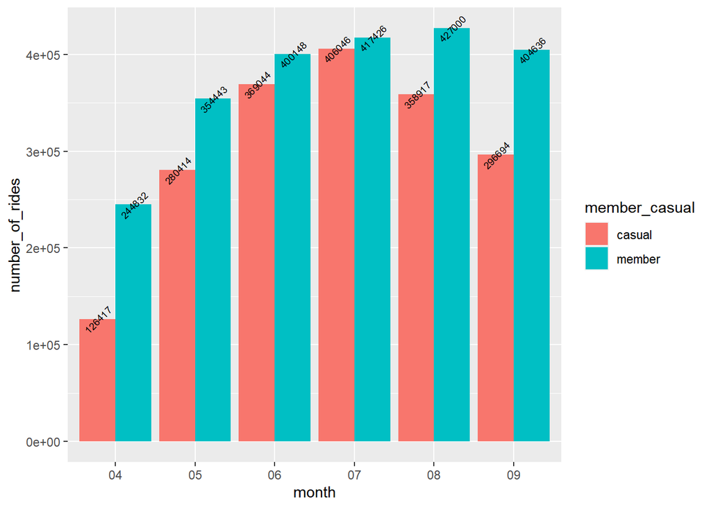

```r
all_trips_v2 %>%
  drop_na() %>%
  group_by(member_casual, month) %>%
  summarise(number_of_rides=n()) %>%
  arrange(member_casual, month) %>%
  ggplot(aes(month, number_of_rides, fill=member_casual))+
  geom_col(position = "dodge")+
  geom_text(aes(label=number_of_rides), position= position_dodge(0.9), vjust = 0.5, size = 2.5, angle = 45)
```

## Kesimpulan

- Hasil analisis menunjukkan tren Pengendara casual lebih lama dalam menggunakan sepeda dari pada pengendara member
- Tren lain yang ditemukan adalah pengendara member lebih banyak jumlahnya dalam mengendarai sepeda dari bulan April sampai September
- Pengendara member lebih banyak menggunakan sepeda di hari kerja yaitu senin sampai jumat, sementara pengendara casual lebih banyak menggunakan sepeda di hari libur yaitu sabtu dan minggu
- Pengendara casual yang beralih ke pengendara member, pengendara mungkin memutuskan untuk menggunakan sepeda secara rutinitas
- Cara media digital untuk mempengaruhi pengendara casual adalah dengan cara memberikan potongan harga untuk pengendara casual yang sudah pernah membeli tiket lebih dari 30 atau dengan kondisi tertentu Serta menjelaskan apa saja keuntungan menjadi pengendara member